# SQL 패밀리레스토랑 데이터 분석

## 01. 환경분석

- 패밀리 레스토랑 신규 매출 분석하기

```python
select * from item;
select * from order_info;
select * from reservation;
select * from customer;
select * from address;
```

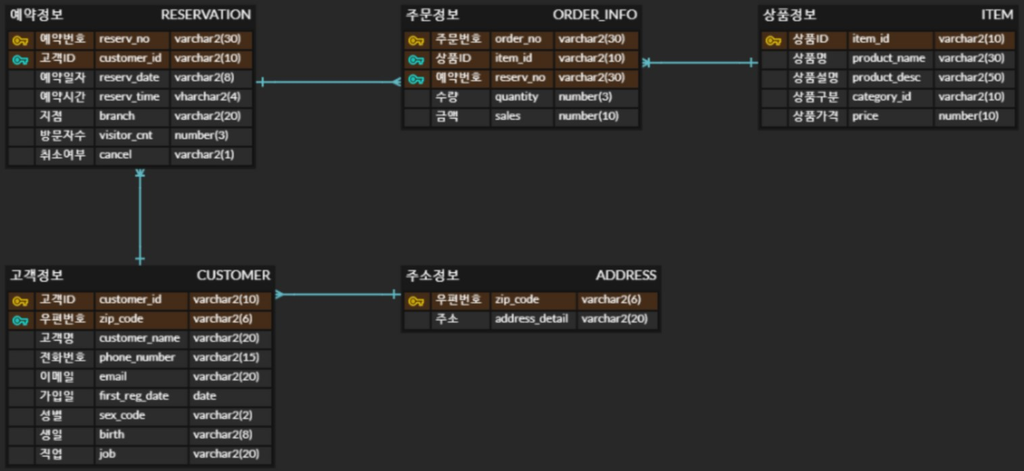

```python
from IPython.display import Image
Image(filename=r'C:\KDigital\python\jupyter\SQL\0.jpg')
```

## 02. 매출 분석

- 전체 상품의 주문건, 총 매출, 평균 매출, 최고 매출, 최저 매출

```python
select
    count(*) as 총주문건,
    sum(sales) as 총매출합계,
    round(avg(sales)) as 평균매출,
    max(sales) as 최고매출,
    min(sales) as 최저매출
from order_info;
```

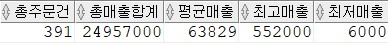

```python
Image(filename=r'C:\KDigital\python\jupyter\SQL\2.jpg')
```

## 03. 매출 비교분석

```python
select
    count(*) 총주문건수,
    sum(sales) 총매출합계,
    sum(decode(item_id, 'M0001', 1,0)) 온라인전용상품주문건수,
    sum(decode(item_id, 'M0001', sales,0)) 온라인전용상품매출합계,
    round(sum(decode(item_id,'M0001', 1, 0))/count(*) * 100,2) 주문건수비율,
    round(sum(decode(item_id, 'M0001', sales,0))/sum(sales) * 100,2) 매출합계비율
from order_info;
```

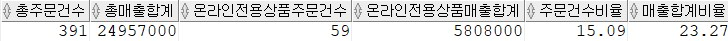

```python
Image(filename=r'C:\KDigital\python\jupyter\SQL\3.jpg')
```

## 04. 상품별 매출 분석

- 전체 상품별 매출 합계를 높은 매출액 순으로 확인해보자.

```python
select
    oi.item_id,
    i.product_name,
    sum(sales) as 매출합계
from order_info oi left join item i
on oi.item_id = i.item_id
group by oi.item_id, i.product_name
order by 매출합계 desc;
```

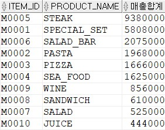

```python
Image(filename=r'C:\KDigital\python\jupyter\SQL\4.jpg')
```

## 05. 월별 상품 매출 분석(시계열 분석)

- 모든 상품의 월별 매출액 출력

```python
select
    SUBSTR(RESERV_NO,1,6) 년월,
    sum(DECODE(item_id, 'M0001', sales, 0)) special_set,
    sum(DECODE(item_id, 'M0002', sales, 0)) pasta,
    sum(DECODE(item_id, 'M0003', sales, 0)) pizza,
    sum(DECODE(item_id, 'M0004', sales, 0)) sea_food,
    sum(DECODE(item_id, 'M0005', sales, 0)) steak,
    sum(DECODE(item_id, 'M0006', sales, 0)) salad_bar,
    sum(DECODE(item_id, 'M0007', sales, 0)) salad,
    sum(DECODE(item_id, 'M0008', sales, 0)) sandwitch,
    sum(DECODE(item_id, 'M0009', sales, 0)) wine,
    sum(DECODE(item_id, 'M0010', sales, 0)) juice
from order_info
group by SUBSTR(RESERV_NO,1,6)
order by 년월;
```

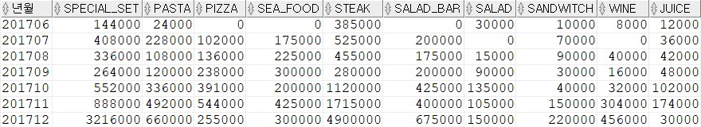

```python
Image(filename=r'C:\KDigital\python\jupyter\SQL\5.jpg')
```

## 06. 월별 총매출, 전용상품매출 비교 분석

- 월별 총 매출액과 전용 상품 매출액 출력

```python
select
    SUBSTR(reserv_no,1,6) 년월
    , sum(sales)
    , sum(DECODE(item_id, 'M0001', sales, 0)) special_set
from order_info
group by SUBSTR(RESERV_NO,1,6)
order by 년월;
```

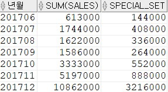

```python
Image(filename=r'C:\KDigital\python\jupyter\SQL\6.jpg')
```

## 07. 매출 기여율

- 전체 매출 중 전용상품의 매출 기여도가 얼마인지 알아보자.
- 기존 월별 추이 분석에 기여율을 추가해 보자.

```python
select
    substr(reserv_no,1,6) 년월,
    sum(decode(item_id, 'M0001', 0, sales)) etc,
    sum(decode(item_id, 'M0001', sales, 0)) special_set,
    round(sum(decode(item_id, 'M0001', sales, 0)) / sum(sales) * 100,1) 매출기여율
from order_info
group by substr(reserv_no,1,6)
order by 년월;
```

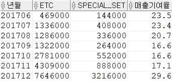

```python
Image(filename=r'C:\KDigital\python\jupyter\SQL\7.jpg')
```

## 08. 예약 완료/취소건 분석

```python
select
    substr(RESERV_DATE,1,6) 년월,
    sum(sales) - sum(decode(item_id, 'M0001', sales, 0)) etc,
    sum(decode(item_id, 'M0001', sales, 0)) special_set,
    round(sum(decode(item_id, 'M0001', sales, 0)) / sum(sales) * 100,1) 매출기여율,
    count(*) 총주문건수,
    sum(decode(cancel, 'N', 1,0)) 예약완료건,
    sum(decode(cancel, 'Y', 1,0)) 예약취소건
from reservation r left join order_info o
on r.RESERV_NO = o.RESERV_NO
group by substr(RESERV_DATE,1,6)
order by 년월;
```

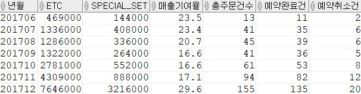

```python
Image(filename=r'C:\KDigital\python\jupyter\SQL\8.jpg')
```

## 09. 월별 취소율 추이 분석

```python
select
    substr(RESERV_DATE,1,6) 년월,
    count(*) 총주문건수,
    sum(decode(cancel, 'N', 1,0)) 예약완료건,
    sum(decode(cancel, 'Y', 1,0)) 예약취소건,
    round((sum(decode(cancel, 'Y', 1,0)) / count(*))*100,1) || '%' 예약취소율
from reservation r left join order_info o
on r.RESERV_NO = o.RESERV_NO
group by substr(RESERV_DATE,1,6)
order by 년월;
```

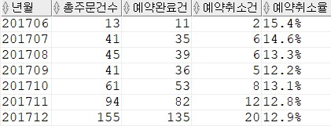

```python
Image(filename=r'C:\KDigital\python\jupyter\SQL\9.jpg')
```

## 10. 요일별 매출 분석

- 월별 전용 상품 매출액을 요일별로 구분해 출력

```python
select
    substr(reserv_date,1,6) 년월,
    'SPECIAL_SET' 상품명,
    sum(decode(to_char(to_date(r.reserv_date),'day'), '일요일', sales, 0)) 일요일,
    sum(decode(to_char(to_date(r.reserv_date),'day'), '월요일', sales, 0)) 월요일,
    sum(decode(to_char(to_date(r.reserv_date),'day'), '화요일', sales, 0)) 화요일,
    sum(decode(to_char(to_date(r.reserv_date),'day'), '수요일', sales, 0)) 수요일,
    sum(decode(to_char(to_date(r.reserv_date),'day'), '목요일', sales, 0)) 목요일,
    sum(decode(to_char(to_date(r.reserv_date),'day'), '금요일', sales, 0)) 금요일,
    sum(decode(to_char(to_date(r.reserv_date),'day'), '토요일', sales, 0)) 토요일
from reservation r  join order_info o on r.reserv_no = o.reserv_no
join item i on o.item_id = i.item_id
where i.item_id = 'M0001'
group by substr(reserv_date,1,6)
order by 년월;
```

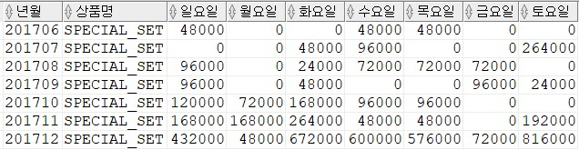

```python
Image(filename=r'C:\KDigital\python\jupyter\SQL\10.jpg')
```

## 11. 월별 전용 상품 실적 순위 분석

```python
select * from
(select
    substr(reserv_date,1,6) 년월
    , branch 지점
    , sum(sales) 매출액
    , rank() over(partition by substr(reserv_date,1,6)
        order by sum(sales) desc) 순위
from reservation r join order_info o
on r.reserv_no = o.reserv_no
where o.item_id = 'M0001'
group by substr(reserv_date,1,6), branch
order by 년월, 매출액 desc)
where 순위 = 1;
```

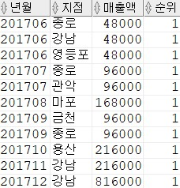

```python
Image(filename=r'C:\KDigital\python\jupyter\SQL\11.jpg')
```

## 12. 고객 특징 분석

```python
select
    count(*) 고객수
    , sum(decode(sex_code, 'M', 1, 0) ) 남자
    , sum(decode(sex_code, 'F', 1, 0) ) 여자
    , round(avg(months_between(sysdate, to_date(birth))/12),2) 평균나이
from customer;
```

[output not shown]

```python
Image(filename=r'C:\KDigital\python\jupyter\SQL\12.jpg')
```

[output not shown]

## 13. 개인별 매출 분석

- 개인별 전체 상품 주문건수, 총 매출, 전용상품 주문건수, 전상품 매출 출력

```python
select
    c.customer_id 고객아이디
    , c.customer_name 고객명
    , count(o.sales) 전체상품주문건수
    , sum(o.sales) 총매출
    , count(DECODE(o.item_id, 'M0001', sales, 0)) 전용상품주문건수
    , sum(DECODE(o.item_id, 'M0001', sales, 0)) 전용상품매출
from customer c join reservation r on c.customer_id = r.customer_id
join order_info o on o.reserv_no = r.reserv_no
group by c.customer_id, c.customer_name
order by 전용상품매출 desc;
```

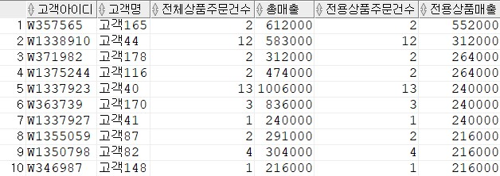

```python
Image(filename=r'C:\KDigital\python\jupyter\SQL\13-1.jpg')
```

...

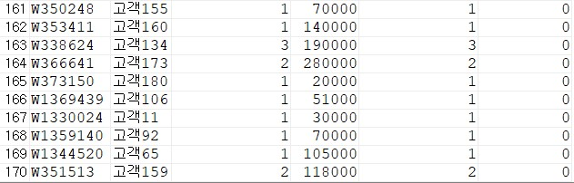

```python
Image(filename=r'C:\KDigital\python\jupyter\SQL\13-2.jpg')
```

## 14. 상위 매출 기준 10위 고객

- 전용 상품 매출 기준 상위 10위 고객 출력 (row_number)

```python
select * from
(select
    c.customer_id 고객아이디
    , c.customer_name 고객명
    , sum(DECODE(o.item_id, 'M0001', sales, 0)) 전용상품매출
    , row_number() over (order by sum(DECODE(o.item_id, 'M0001', sales, 0)) desc) 순위
from customer c join reservation r on c.customer_id = r.customer_id
join order_info o on o.reserv_no = r.reserv_no
group by c.customer_id, c.customer_name)
where 순위 <= 10;
```

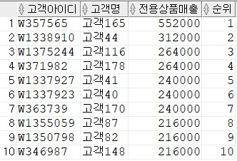

```python
Image(filename=r'C:\KDigital\python\jupyter\SQL\14.jpg')
```